# BrightBytes Data Challenge

### Intro

**Objective**: Use this dataset to help understand what factors are the best predictors of postsecondary enrollment, and offer suggestions to operationalize those insights to help Brightbytes.

**Methodology**: Make the target binary. 1 = Post secondary (Only focusing on Bachelors for this exercise), 0 = non-post secondary (Indicated by a -7). While identifying predictors of this response I can identify factors that are associated with higher rates of post secondary education. One key question to think about when identifying relationships: Is it the variable value that makes a student more likely to go to college, or is it the type of student they are that makes the that variables value more likely to occur.

**Load libraries and data**

```r
library(tidyverse)
df <- read_csv('/home/will/link_to_wjburton/Documents/Professional Info/Company Code Challenges/BrightBytes/HSLS_2009_v3_0/students.csv')
```

**Quick data summary**

```r
df %>% data.frame() %>% str()
```

```
'data.frame':   23503 obs. of  60 variables:
 $ X1             : int  1 2 3 4 5 6 7 8 9 10 ...
 $ STU_ID         : int  10001 10002 10003 10004 10005 10006 10007 10008 10009 10010 ...
 $ SCH_ID         : int  -5 -5 -5 -5 -5 -5 -5 -5 -5 -5 ...
 $ X1SEX          : int  1 2 2 2 1 2 2 1 1 2 ...
 $ X1RACE         : int  8 8 3 8 8 8 8 8 8 8 ...
 $ X1PAR1OCC_STEM1: int  0 0 0 0 0 4 0 0 0 0 ...
 $ X1SES          : num  1.564 -0.37 1.274 0.55 0.149 ...
 $ X3LOCALE       : int  4 4 2 2 1 3 4 3 4 2 ...
 $ X3STATE        : int  -5 -5 -5 -5 -5 -5 -5 -5 -5 -5 ...
 $ X3T1CREDALG1   : int  1 1 1 1 1 1 1 1 1 1 ...
 $ X3T1CREDALG2   : int  1 0 1 1 0 1 1 1 1 1 ...
 $ X3T1CREDINTM   : int  0 0 0 0 0 0 0 0 0 0 ...
 $ X3T1CREDPREC   : int  0 0 1 0 1 0 0 1 0 0 ...
 $ X3T1CREDSTAT   : int  1 0 1 0 0 0 0 0 0 0 ...
```

[output cut: 46 more lines]

```r
#df %>% summary()
df %>% head()
```

| X1 | STU_ID | SCH_ID | X1SEX | X1RACE | X1PAR1OCC_STEM1 | X1SES | X3LOCALE | X3STATE | X3T1CREDALG1 | X3T1CREDALG2 | X3T1CREDINTM | X3T1CREDPREC | X3T1CREDSTAT | X3TWHENALG1 | S3ENROLLHS13 | S3AP | S3IB | S3DUAL | S3APMATH | S3APSCIENCE | S3APOTHER | S3IBMATH | S3IBSCIENCE | S3IBOTHER | S3DUALMATH | S3DUALSCIENCE | S3DUALOTHER | S3CNSLCLG | S3CNSLAID | … |
| --- | --- | --- | --- | --- | --- | --- | --- | --- | --- | --- | --- | --- | --- | --- | --- | --- | --- | --- | --- | --- | --- | --- | --- | --- | --- | --- | --- | --- | --- | --- |
| 1 | 10001 | -5 | 1 | 8 | 0 | 1.5644 | 4 | -5 | 1 | 1 | 0 | 0 | 1 | 4 | -7 | 1 | 2 | 2 | 1 | 0 | 1 | -7 | -7 | -7 | -7 | -7 | -7 | 1 | 1 | … |
| 2 | 10002 | -5 | 2 | 8 | 0 | -0.3699 | 4 | -5 | 1 | 0 | 0 | 0 | 0 | 5 | -7 | -7 | -7 | -7 | -7 | -7 | -7 | -7 | -7 | -7 | -7 | -7 | -7 | 1 | 2 | … |
| 3 | 10003 | -5 | 2 | 3 | 0 | 1.2741 | 2 | -5 | 1 | 1 | 0 | 1 | 1 | 10 | -7 | -7 | -7 | -7 | -7 | -7 | -7 | -7 | -7 | -7 | -7 | -7 | -7 | 1 | 1 | … |
| 4 | 10004 | -5 | 2 | 8 | 0 | 0.5498 | 2 | -5 | 1 | 1 | 0 | 0 | 0 | 4 | -8 | -8 | -8 | -8 | -8 | -8 | -8 | -8 | -8 | -8 | -8 | -8 | -8 | -8 | -8 | … |
| 5 | 10005 | -5 | 1 | 8 | 0 | 0.1495 | 1 | -5 | 1 | 0 | 0 | 1 | 0 | 10 | -7 | 1 | 2 | 2 | 1 | 1 | 0 | -7 | -7 | -7 | -7 | -7 | -7 | 1 | 2 | … |
| 6 | 10006 | -5 | 2 | 8 | 4 | 1.0639 | 3 | -5 | 1 | 1 | 0 | 0 | 0 | 4 | -7 | 3 | 2 | 1 | -7 | -7 | -7 | -7 | -7 | -7 | 0 | 0 | 1 | 1 | 1 | … |

```r
df %>% tail()
```

| X1 | STU_ID | SCH_ID | X1SEX | X1RACE | X1PAR1OCC_STEM1 | X1SES | X3LOCALE | X3STATE | X3T1CREDALG1 | X3T1CREDALG2 | X3T1CREDINTM | X3T1CREDPREC | X3T1CREDSTAT | X3TWHENALG1 | S3ENROLLHS13 | S3AP | S3IB | S3DUAL | S3APMATH | S3APSCIENCE | S3APOTHER | S3IBMATH | S3IBSCIENCE | S3IBOTHER | S3DUALMATH | S3DUALSCIENCE | S3DUALOTHER | S3CNSLCLG | S3CNSLAID | … |
| --- | --- | --- | --- | --- | --- | --- | --- | --- | --- | --- | --- | --- | --- | --- | --- | --- | --- | --- | --- | --- | --- | --- | --- | --- | --- | --- | --- | --- | --- | --- |
| 23498 | 35200 | -5 | 1 | 8 | 0 | 1.2033 | 4 | -5 | 1 | 1 | 0 | 1 | 0 | 8 | -7 | 1 | 2 | 1 | 0 | 1 | 1 | -7 | -7 | -7 | 0 | 1 | 1 | 1 | 2 | … |
| 23499 | 35202 | -5 | 2 | 5 | -8 | 0.0205 | 2 | -5 | 1 | 0 | 0 | 0 | 0 | 10 | -7 | -7 | -7 | -7 | -7 | -7 | -7 | -7 | -7 | -7 | -7 | -7 | -7 | -7 | -7 | … |
| 23500 | 35203 | -5 | 2 | 5 | 0 | -1.2098 | 2 | -5 | 1 | 0 | 0 | 0 | 0 | 5 | 2 | -7 | -7 | -7 | -7 | -7 | -7 | -7 | -7 | -7 | -7 | -7 | -7 | 3 | 2 | … |
| 23501 | 35204 | -5 | 2 | 8 | 0 | -0.0649 | 2 | -5 | 1 | 1 | 0 | 1 | 0 | 4 | -7 | -7 | -7 | -7 | -7 | -7 | -7 | -7 | -7 | -7 | -7 | -7 | -7 | 1 | 1 | … |
| 23502 | 35205 | -5 | 1 | 8 | 0 | 0.8512 | 2 | -5 | 1 | 0 | 0 | 0 | 0 | 4 | -7 | 1 | 2 | 1 | 0 | 0 | 1 | -7 | -7 | -7 | 0 | 0 | 1 | 2 | 2 | … |
| 23503 | 35206 | -5 | 2 | 8 | 1 | 1.6397 | 1 | -5 | 1 | 1 | 0 | 1 | 1 | 10 | -7 | 1 | 2 | 2 | 1 | 1 | 1 | -7 | -7 | -7 | -7 | -7 | -7 | 1 | 2 | … |

All variables are in fact integers/numeric. One issue noticed is that there are many negative values. After a quick scan on the website I found these are:

• −5 = “Data Suppressed”—indicates values that are available on the restricted-use data but suppressed on the public-use data.  
• −7 = “Item legitimate skip/NA”—indicates items that are programmatically skipped based on rules in the questionnaire and are not applicable to those respondents.  
• −8 = “Nonrespondent/component NA”—indicates that data are not available because of unit nonresponse or the interview component did not apply (e.g., student has no mathematics class, thus the mathematics teacher interview does not apply).  
• −9 = “Missing”—indicates item level missing where the question may apply to the respondent but it is not answered, or the question is not administered because the gate/introductory question is not answered.

### Exploration & defining the response

Based on data dictionary, only keep variables that would be useful for building predictive models, and rename columns to be more interpretable. In this dataset I only keep rows with S3PROGLEVEL having values of -7 and 1. It is then converted to binary with 1 = postsecondary (bachelors), and -7 = not postsecondary

```r
table(df$S3PROGLEVEL)
```

```
  -9   -8   -7    1    2    3    4    5    6
 173 4945 5022 8109 2510  554  752  255 1183
```

```r
df <- df %>%
      select(-one_of('X1','S3FALLHSID', 'X3STATE', 'SCH_ID', 'S3ENROLLHS13', 'S3FOCUS','S3CLGFT',
                     'S3WORKFT', 'S3CLGLVL', 'S3CLGSTATE', 'S3AAB4BA', 'S3BATRANSFER', 'S3REPUTATION',
                     'S3COSTATTEND','S3DISTANCE',
                     'S3CNSLCLG', 'S3CNSLAID', 'S3CNSLJOB', 'S3JOBPLC', 'S34YRBAPLC', 'S3SPORTS',
                     'S3SOCIALLIFE', 'S3ONLINE', 'S3NODEBT', 'S3CANAFFORD',
                     'S3INELIGIBLE', 'S3DKHOW', 'S3DKCOULD', 'S3NOPOSTSEC', 'S3FAMNOTQUAL',
                     'S3DONOTWANT', 'S3NOCLGOTHRSN', 'S3WHYNOTCLG', 'STU_ID','S3APPFAFSA')) %>%
      rename(parent_occ = X1PAR1OCC_STEM1, socio_econ = X1SES, location = X3LOCALE, alg1 = X3T1CREDALG1,
             alg2 = X3T1CREDALG2, int_math = X3T1CREDINTM,
             pre_calc = X3T1CREDPREC, stat = X3T1CREDSTAT, when_alg1 = X3TWHENALG1,
             ap_class = S3AP, ib_class = S3IB, col_class = S3DUAL, ap_math = S3APMATH,
             ap_sci = S3APSCIENCE, ap_other = S3APOTHER, ib_math = S3IBMATH, ib_sci = S3IBSCIENCE,
             ib_other = S3IBOTHER, col_math = S3DUALMATH, col_sci = S3DUALSCIENCE,
             col_other = S3DUALOTHER, col_influence = S3CLGINFLU,
             post_second = S3PROGLEVEL) %>%
      filter(post_second == -7 | post_second == 1) %>%
      mutate(post_second  = ifelse(post_second == -7,0,1)) %>%
      mutate_if(is.integer, as.factor)
#split the data into training and testing
set.seed(10)
train_samp <- sample(1:nrow(df), size = 0.9 * nrow(df))
train_df <- df[train_samp,]
test_df <- df[-train_samp,]
```

Instead of exploring all variables and associations, lets use a random forest to pull out the variables that could be of the most useful for predicting post secondary education.

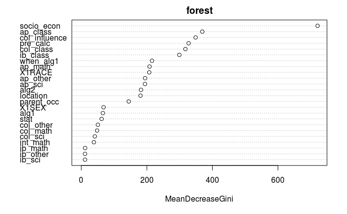

```r
forest <- randomForest::randomForest(factor(post_second) ~ ., train_df)
randomForest::varImpPlot(forest)
```

Now I’ll dive into a couple of the most predictive variables

**socio-econ**

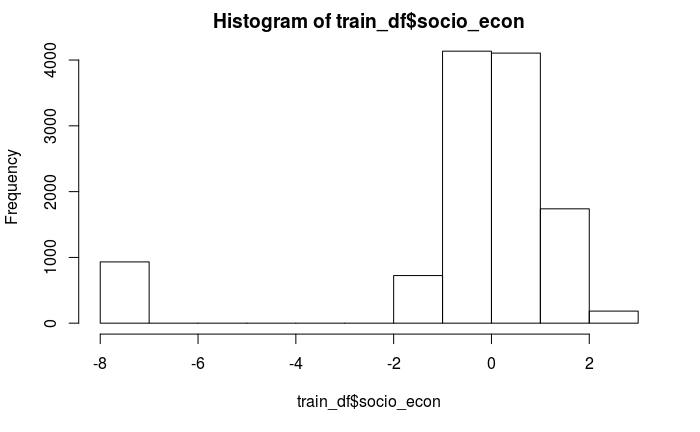

```r
#Missing ~ 1000 socio economic values, but this is an incredibly strong predictor. I'll just add an indicator if it is = -8
hist(train_df$socio_econ)
```

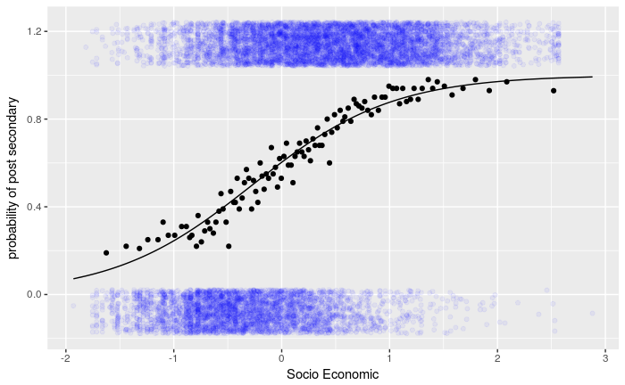

```r
plot_continuous(train_df$socio_econ[train_df$socio_econ > -8],  n = 100,
                response = train_df$post_second[train_df$socio_econ > -8], max_poly_degree = 1, log_odds = F, variable_name = 'Socio Economic')
```

**ap_class**

```r
table(train_df$ap_class, train_df$post_second)
```

```
        0    1
  -9   85   31
  -7 3156 1794
  -4  444  256
  1   470 4459
  2   225  605
  3   147  145
```

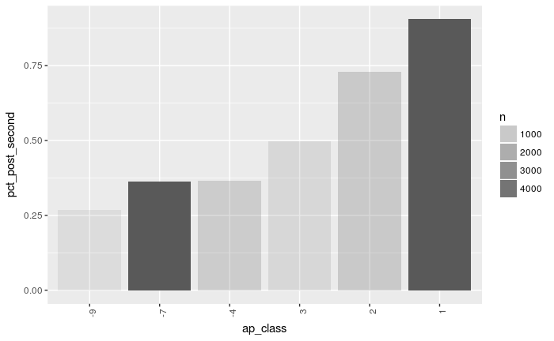

```r
train_df %>%
  group_by(ap_class) %>%
  summarise(pct_post_second = sum(post_second)/n(),
            n = n()) %>%
  arrange(pct_post_second) %>%
  mutate(ap_class = factor(ap_class,levels = unique(ap_class))) %>%
  ggplot(aes(ap_class, pct_post_second)) + geom_bar(aes(alpha = n),stat = 'identity') +
  theme(axis.text.x = element_text(angle = 90, hjust = 1))
```

**college influence**

```r
table(train_df$col_influence, train_df$post_second)
```

```
        0    1
  -9    8   11
  -4  444  256
  1   152  184
  2     9   24
  3   265  324
  4  1688 4393
  5   348  225
  6   153   81
  7    18   10
  8    91    2
  9    26   57
  10  711 1386
  11  392  227
  12  222  110
```

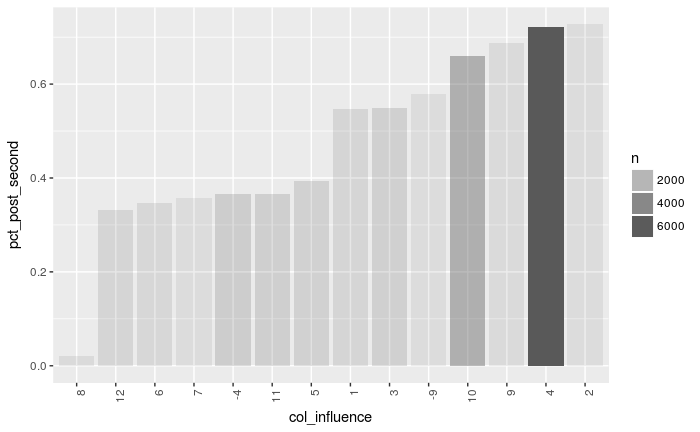

```r
train_df %>%
  group_by(col_influence) %>%
  summarise(pct_post_second = sum(post_second)/n(),
            n = n()) %>%
  arrange(pct_post_second) %>%
  mutate(col_influence = factor(col_influence,levels = unique(col_influence))) %>%
  ggplot(aes(col_influence, pct_post_second)) + geom_bar(aes(alpha = n),stat = 'identity') +
  theme(axis.text.x = element_text(angle = 90, hjust = 1))
```

**ib_class**

```r
table(train_df$ib_class, train_df$post_second)
```

```
        0    1
  -9   83   39
  -7 3156 1794
  -4  444  256
  1    35  247
  2   669 4739
  3   140  215
```

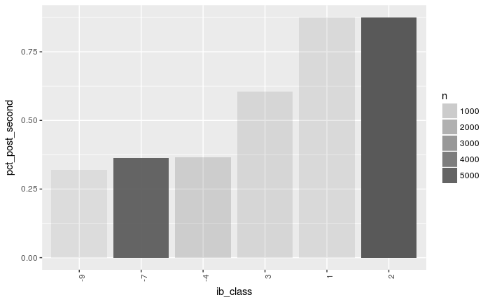

```r
train_df %>%
  group_by(ib_class) %>%
  summarise(pct_post_second = sum(post_second)/n(),
            n = n()) %>%
  arrange(pct_post_second) %>%
  mutate(ib_class = factor(ib_class,levels = unique(ib_class))) %>%
  ggplot(aes(ib_class, pct_post_second)) + geom_bar(aes(alpha = n),stat = 'identity') +
  theme(axis.text.x = element_text(angle = 90, hjust = 1))
```

**col_class**

```r
table(train_df$col_class, train_df$post_second)
```

```
        0    1
  -9   82   41
  -7 3156 1794
  -4  444  256
  1   289 1865
  2   426 3070
  3   130  264
```

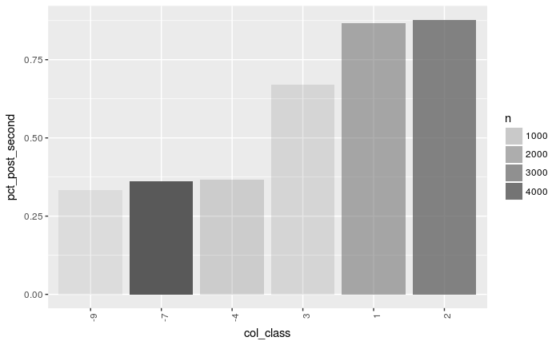

```r
train_df %>%
  group_by(col_class) %>%
  summarise(pct_post_second = sum(post_second)/n(),
            n = n()) %>%
  filter(n > 30) %>%
  arrange(pct_post_second) %>%
  mutate(col_class = factor(col_class,levels = unique(col_class))) %>%
  ggplot(aes(col_class, pct_post_second)) + geom_bar(aes(alpha = n),stat = 'identity') +
  theme(axis.text.x = element_text(angle = 90, hjust = 1))
```

**Parent occupation**

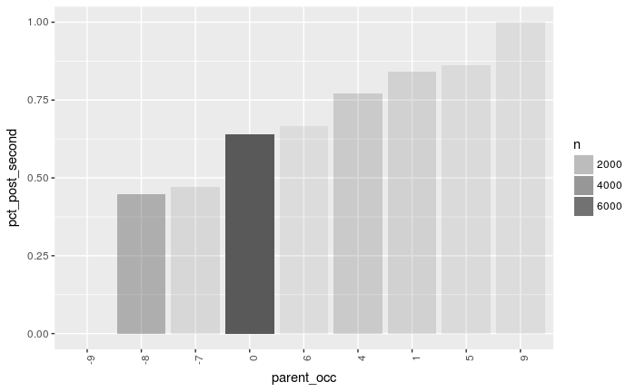

```r
train_df %>%
  group_by(parent_occ) %>%
  summarise(pct_post_second = sum(post_second)/n(),
            n = n()) %>%
  arrange(pct_post_second) %>%
  mutate(parent_occ = factor(parent_occ,levels = unique(parent_occ))) %>%
  ggplot(aes(parent_occ, pct_post_second)) + geom_bar(aes(alpha = n),stat = 'identity') +
  theme(axis.text.x = element_text(angle = 90, hjust = 1))
```

**Location**

```r
table(train_df$location, train_df$post_second)
```

```
        0    1
  -9  240   56
  -8    6    2
  1  1060 2394
  2  1133 2346
  3   672  737
  4  1416 1755
```

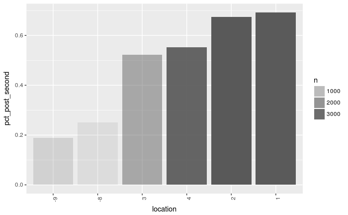

```r
train_df %>%
  group_by(location) %>%
  summarise(pct_post_second = sum(post_second)/n(),
            n = n()) %>%
  arrange(pct_post_second) %>%
  mutate(location = factor(location,levels = unique(location))) %>%
  ggplot(aes(location, pct_post_second)) + geom_bar(aes(alpha = n),stat = 'identity') +
  theme(axis.text.x = element_text(angle = 90, hjust = 1))
```

### Final dataset manipulation

```r
transform_data <- function(df, train = T){
  mod_df <- df %>%
            select(parent_occ, socio_econ, location, ib_class,
            ap_class, col_class, col_influence, post_second) %>%
            mutate_if(is.factor, funs(as.integer(as.character(.)))) %>%
            mutate_if(is.integer, funs(ifelse(as.integer(.) < 0, '_miss',.))) %>%
            mutate_if(is.character, funs(as.factor))

  mod_df <- model.matrix(~., data = mod_df) %>% data.frame() %>%  .[,-1]

  if(train == T){
    keep_vars <- mod_df %>% apply(2,sum) %>% .[.>50] %>% names %>% c('socio_econ')
  }else{
    keep_vars = names(mod_df)
  }

  mod_df <- mod_df %>%
            select(keep_vars) %>%
            mutate(socio_missing = ifelse(socio_econ == -8,1,0),
                   non_ib_ap_col = ifelse(ap_class_miss == 1 & ib_class_miss == 1 & col_class_miss == 1,1,0))
}

clean_train_df <- transform_data(train_df)
clean_test_df <- transform_data(test_df, train = F)
```

### Modeling

I’m choosing to build a logistic regression model so I can interpret the associations with the response

```r
#Forward selection:
#define full logistic model
full_logistic_mod <- glm(post_second ~ ., data = clean_train_df, family = binomial)
#define empty model
nothing <- glm(post_second ~ 1, data = clean_train_df, family = binomial)
#preform forwards, selection, while optimizing AIC
forwards <- step(nothing,
                 scope=list(lower=formula(nothing),upper=formula(full_logistic_mod)), direction="forward", trace = 0)
#check if variables selected were too similar
selected_vars <- clean_train_df %>% select(forwards$coefficients %>% names() %>% .[-1])
#cor(selected_vars)
#remove ap_class_miss, keep non_ib_ap_col
# I'll drop the remaining variables that aren't statistically significant
final_model <- glm(post_second ~ col_influence4 +
                   ap_class3 + socio_econ + socio_missing + ap_class2 + col_influence8 +
                   parent_occ_miss + location_miss + col_influence11 + col_influence6 +
                   col_influence12 + parent_occ4 + location4 + location3 + col_class2 +
                   col_class3 + ib_class3 + col_influence9 + col_influence_miss + non_ib_ap_col,
                   data = clean_train_df, family = binomial)
summary(final_model)
```

```
Call:
glm(formula = post_second ~ col_influence4 + ap_class3 + socio_econ +
    socio_missing + ap_class2 + col_influence8 + parent_occ_miss +
    location_miss + col_influence11 + col_influence6 + col_influence12 +
    parent_occ4 + location4 + location3 + col_class2 + col_class3 +
    ib_class3 + col_influence9 + col_influence_miss + non_ib_ap_col,
    family = binomial, data = clean_train_df)

Deviance Residuals:
    Min       1Q   Median       3Q      Max
-3.2032  -0.7014   0.2383   0.6077   2.5637

Coefficients:
                   Estimate Std. Error z value Pr(>|z|)
(Intercept)         2.76476    0.11051  25.018  < 2e-16 ***
col_influence4      0.46157    0.05706   8.090 5.98e-16 ***
ap_class3          -1.48518    0.16556  -8.971  < 2e-16 ***
socio_econ          1.24004    0.04184  29.639  < 2e-16 ***
socio_missing       9.95395    0.34423  28.916  < 2e-16 ***
ap_class2          -1.43416    0.12220 -11.736  < 2e-16 ***
col_influence8     -4.47395    0.74632  -5.995 2.04e-09 ***
parent_occ_miss    -0.61410    0.06194  -9.914  < 2e-16 ***
location_miss      -1.58659    0.17800  -8.913  < 2e-16 ***
col_influence11    -0.94198    0.11780  -7.997 1.28e-15 ***
col_influence6     -0.84033    0.18143  -4.632 3.63e-06 ***
col_influence12    -0.68885    0.15653  -4.401 1.08e-05 ***
parent_occ4        -0.45707    0.10381  -4.403 1.07e-05 ***
location4          -0.35323    0.05759  -6.134 8.56e-10 ***
location3          -0.44534    0.07769  -5.732 9.93e-09 ***
col_class2         -0.69184    0.11085  -6.241 4.35e-10 ***
col_class3         -0.76353    0.17075  -4.472 7.76e-06 ***
ib_class3          -0.53291    0.16979  -3.139  0.00170 **
col_influence9      0.65158    0.28532   2.284  0.02239 *
col_influence_miss  0.27168    0.09838   2.762  0.00575 **
non_ib_ap_col      -2.99074    0.10697 -27.958  < 2e-16 ***
---
Signif. codes:  0 ‘***’ 0.001 ‘**’ 0.01 ‘*’ 0.05 ‘.’ 0.1 ‘ ’ 1

(Dispersion parameter for binomial family taken to be 1)

    Null deviance: 15729.8  on 11816  degrees of freedom
Residual deviance:  9934.4  on 11796  degrees of freedom
AIC: 9976.4

Number of Fisher Scoring iterations: 6
```

### Model testing

```r
logistic_probs <- predict(final_model, clean_test_df, type = 'response')
logistic_roc <- calculate_ROC(probs = preds, response = clean_test_df$post_second, name =  'Logistic Model')
```

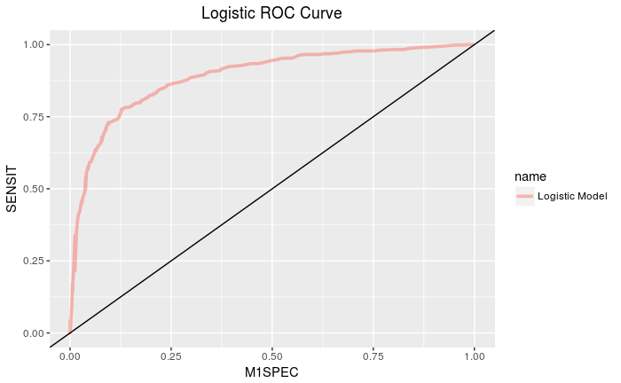

```r
#The model has significant lift over random guessing
ggplot(logistic_roc, aes(x = M1SPEC, y = SENSIT)) + geom_line(aes(color = name), lwd = 1.3, alpha= 0.5) +
  geom_abline(slope = 1, intercept = 0) + xlim(0,1) + ylim(0,1) + ggtitle('Logistic ROC Curve') +
  theme(plot.title = element_text(hjust = 0.5))
```

And the accuracy on unseen data, if the threshold is set to 0.5, comes out to 82% accurate

```r
logistic_preds <- ifelse(logistic_probs > 0.5, 1, 0)
table(logistic_preds, clean_test_df$post_second)
```

```
logistic_preds   0   1
             0 382 124
             1 113 695
```

```r
(382 + 695) / length(logistic_preds)
```

```
[1] 0.8196347
```

### Additional Ideas that weren’t explored:

What Factors are important to Post Secondary Goers (could translate to action):  
S3ONLINE, S3SOCIALLIFE, S3SPORTS, S3JOBPLC, S3DISTANCE, S3COSTATTEND, S3REPUTATION  
What Factors attribute to not going to post secondary (could translate to action):  
S3WHYNOTCLG, S3NOCLGOTHRSN, S3DONOTWANT  
FAFSA Exploration (could translate to action):  
S3APPFAFSA, S3NODEBT, S3CANAFFORD, S3INELIGIBLE, S3DKHOW, S3DKCOULD, S3NOPOSTSEC, S3FAMNOTQUAL

### Functions Used

I had built these functions previously to plot ROC curves and to visualize relationships between a continuous predictor and a binary response

```r
#' Calculate the ROC curve for a given model
#' @description This function calculates the roc curve and returns the data in a data frame
#' @param model  model of interest
#' @param response  response variable
#' @param name  name of model
#' @param probs predicted probabilities
#' @export
calculate_ROC <- function(model = NULL, response, name, probs = NULL){
  df <- NULL
  tp_rates <- NULL
  fp_rates <- NULL
  probs <- if(is.null(probs)){predict(model, type= 'response')} else{probs}
  AUC <- as.numeric(pROC::auc(response, probs))
  for(threshold in 0:200){
    preds <- ifelse(probs >= (threshold/200), 1,0)
    confusion_matrix <- caret::confusionMatrix(preds, response)$table
    POS <- confusion_matrix[2,2]
    NEG <- confusion_matrix[1,1]
    FALPOS <- confusion_matrix[2,1]
    FALNEG <- confusion_matrix[1,2]
    tp_rate <- POS / (POS + FALNEG)
    fp_rate <- FALPOS / (NEG + FALPOS)
    tn_rate <- NEG / (NEG + FALPOS)
    SPECIFICITY  <- tn_rate
    SENSIT <- tp_rate
    M1SPEC <- 1 - SPECIFICITY
    df <- rbind(df, data.frame(name, AUC,'PROB' = threshold/200,
                               POS, NEG, FALPOS, FALNEG, SENSIT,
                               M1SPEC, youden_index = (SENSIT + SPECIFICITY - 1),
                               accuracy = (POS + NEG)/(POS + NEG + FALPOS + FALNEG)))
  }

  return(df)
}
#'Create bins containing equal sample sizes spread across a variable
#'@description Create bins containing equal sample sizes. If the density is not
#'uniform then generic cuts in the data will not produce equal sample sizes among
#'the cuts.
#'@param variable  Variable of interest
#'@param n  The sample size for each bin
create_equal_bins <- function(variable, n){
  place <- 1:length(variable)
  n_bins <- ceiling(length(variable)/n)
  binned_var <- rep(1:n_bins,n) %>% sort %>% .[1:length(variable)]

  data.frame(place, variable) %>%
    arrange(variable) %>%
    mutate(binned_var = binned_var) %>%
    group_by(binned_var) %>%
    mutate(point = median(variable)) %>%
    ungroup() %>%
    arrange(place) -> out

  return(out)
}
#'Plot a continuous variable against a binary response
#'@description Plot a continuous variable against a binary response by
#'binning the variables and looking at the proportion of the response in each bin
#'@param variable  A binned version of the continuous variable
#'@param int An interaction term to add to the model. Can be used to fit more complicated relationships
#'@param n The number of datapoints for each condensed point
#'@param response Binary response variable
#'@param out Output the data used to create the plot or not. Accepts values of TRUE or FALSE
#'@param max_poly_degree The highest degree of polynomial to use for modeling
#'@param variable_name Name of the variable, Will be the title of the x-axis
#'@param jitter_height The random jitter of the actual points. the default may be too large or small
#'@param log_odds Should the y-axis be in terms of log odds or probability. T = log odds, F = Probability
#'@export
plot_continuous <- function(variable, int = NULL, n = 30, response, out = F,
                            max_poly_degree = 1, variable_name = 'variable',
                            jitter_height = 0.1, log_odds = T){
  df <- create_equal_bins(variable, n)
  df <- data.frame(df, response) %>% na.omit()

  df %>%
  group_by(point) %>%
  summarise(prob_warm = sum(response)/n(),
            n = n()) %>%
  mutate(odds = prob_warm/(1-prob_warm)) %>%
  mutate(log_odds = log(odds)) -> association_tbl
  if(is.null(int)){
    log_mod <- glm(response ~ poly(variable,max_poly_degree) ,data = df, family = "binomial") } else {
       log_mod <- glm(response ~ poly(variable,max_poly_degree) + int + I(variable * int) ,data = df, family = "binomial")
    }

  probs <- predict(log_mod , type = 'response')
  df$pred_prob <- probs
  df$pred_log_odds <- log(probs/(1-probs))
  max_log_odds <- max(association_tbl$log_odds[!is.infinite(association_tbl$log_odds)])
  min_log_odds <- min(association_tbl$log_odds[!is.infinite(association_tbl$log_odds)])
  add <- max(abs(association_tbl$log_odds[!is.infinite(association_tbl$log_odds)]))
  if(log_odds == T){
    df$plot_point <- ifelse(df$response == 1, max_log_odds + .1*add,
                            min_log_odds - .1*add)
    print(ggplot()+ geom_point(aes(x = association_tbl$point, y = association_tbl$log_odds)) +
            geom_line(aes(x = df$variable, y = df$pred_log_odds))+
            geom_jitter(aes(x = df$variable, y = df$plot_point),
                           color = 'blue', alpha = .05, height = jitter_height, width = 0) +
            xlab(variable_name) + ylab('log odds of post secondary'))
  } else{
    df$plot_point <- ifelse(df$response == 1,max(df$pred_prob) + 0.15, min(df$pred_prob) - 0.15 )
    print(ggplot()+ geom_point(aes(x = association_tbl$point, y = association_tbl$prob_warm)) +
            geom_line(aes(x = df$variable, y = df$pred_prob))+
            geom_jitter(aes(x = df$variable, y = df$plot_point),
                        color = 'blue', alpha = .05, height = jitter_height, width = 0) +
            xlab(variable_name) + ylab('probability of post secondary'))
  }
  if(out == T){
    return(list('points' = association_tbl, 'line' = df))
  }
}
```